# Day 24 Notebook

This reads the starting values into a dictionary and then the gates into a list. Each gate is a vector in the format c(wire1, operator, wire2, wire3). I also get the highest z value.

```
input<-read_lines("Day24Sample2.txt")

### the values are in a dictionary
wirevalues<-dict()
### the gates/rules are in a list
gates<-list()
highz<- -Inf
blank<-which(input=="")
xvals<-c()
yvals<-c()
for(i in 1:(blank-1)){
  x<-unlist(str_split(input[i],": "))
  wirevalues$set(x[1],as.numeric(x[2]))
  if(str_starts(x[1],"x")){xvals[as.numeric(str_sub(x[1],start=2))+1]<-as.numeric(x[2])}
  if(str_starts(x[1],"y")){yvals[as.numeric(str_sub(x[1],start=2))+1]<-as.numeric(x[2])}}
for(i in (blank+1):length(input)){
    x<-unlist(str_split(input[i]," "))[c(1:3,5)]
    ### look for the highest z
    if(str_starts(x[1],"z")){highz<-max(highz,as.numeric(str_sub(x[1],start=2)))}
    if(str_starts(x[3],"z")){highz<-max(highz,as.numeric(str_sub(x[3],start=2)))}
    if(str_starts(x[4],"z")){highz<-max(highz,as.numeric(str_sub(x[4],start=2)))}
    gates<-c(gates,list(x))}
```

## Part 1

This simply runs through all of the available rules again and again until there’s a value for every z.

```
getzs<-function(wv,g,hz){
  ### get the out vector
  zvals<-rep(5,hz+1)
  ### while any of the zs don't have values yet,
  while(any(zvals==5)){
    i<-1
    ### run through the gates
    while(i<=length(g)){
      wire<-g[[i]]
      if(wv$has(wire[1])&&wv$has(wire[3])){
      otpt<-switch(wire[2],
             "AND"={(wv$get(wire[1])&&wv$get(wire[3]))},
             "OR"={(wv$get(wire[1])||wv$get(wire[3]))},
             "XOR"={(xor(wv$get(wire[1]),wv$get(wire[3])))},
             {cat("unknown\n",unlist(wire),"\n")})
        ### set the gate
        wv$set(wire[4],otpt)
        ### if the output wire is something that begins with z, update the zvector
        otpt<-as.numeric(otpt)
        if(str_starts(wire[4],"z")){zvals[as.numeric(str_sub(wire[4],start=2))+1]<-otpt}
        ### get rid of that instruction
        g<-g[-i]
      }else{i<-i+1}}}
  zdigits<-0
  ### translates z from binary to dec
  for(i in length(zvals):1){
    zdigits<-2*zdigits+zvals[i]}
list(zvals,zdigits)}
```

```
p1<-getzs(wirevalues,gates,highz)
part1<-p1[[2]]
part1
```

```
[1] 2024
```

## Part 2

Using my actual data, but input the same way. Also creates x, y, and x+y in decimal form

Put all the gates into a dataframe, because I find them easier to look through than lists

```
gatesdf<-as.data.frame(matrix(nrow=0,ncol=4))
for(i in 1:length(gates)){gatesdf<-rbind(gatesdf,gates[[i]])}
colnames(gatesdf)<-c("a","op","b","c")
```

This shows the values of x, y, x+y and z followed by a graph.

If x+y = z and the graph isn’t wonky, the gates and wires are correct. This function adds x & y and shows the gates in graphical form

```
x= 22344970157743
y= 28135262594079
x+y= 50480232751822
z= 50411513338638
      [,1] [,2] [,3] [,4] [,5] [,6] [,7] [,8] [,9] [,10] [,11] [,12] [,13] [,14] [,15]
xs       1    1    1    1    0    1    0    1    0     1     1     1     1     1     0
ys       1    1    1    1    1    0    0    0    0     0     1     0     0     1     0
added    0    1    1    1    0    0    1    1    0     1     0     0     0     1     1
zs       0    1    1    1    0    0    0    0    1     1     0     1     1     0     1
      [,1] [,2] [,3] [,4] [,5] [,6] [,7] [,8] [,9] [,10] [,11] [,12] [,13] [,14] [,15]
xs       0    0    1    0    0    0    0    0    0     0     0     0     1     1     0
ys       0    1    0    1    0    1    0    1    0     0     0     0     0     0     0
added    0    1    1    1    0    1    0    1    0     0     0     0     1     1     0
zs       0    0    0    0    1    1    0    1    0     0     0     0     1     1     0
      [,1] [,2] [,3] [,4] [,5] [,6] [,7] [,8] [,9] [,10] [,11] [,12] [,13] [,14] [,15]
xs       0    1    0    1    0    0    1    0    1     0     0     0     1     0     1
ys       1    1    0    1    1    0    1    0    0     1     1     0     0     1     1
added    1    0    1    0    0    1    0    1    1     1     1     0     1     1     0
zs       1    0    1    0    0    1    1    0    1     1     1     0     1     1     0
```

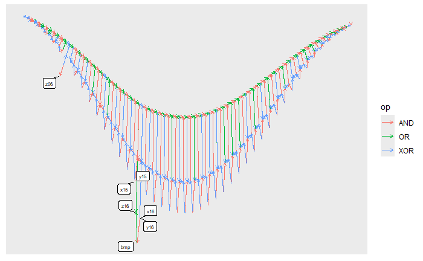

The added numbers show an issue around 6. The graph shows issues around 6, around 11, around 15/16, and around 36

We can also look at the gates in a slightly different form

```
gatecheck<-function(){

### get lists of all of the different gates
xorvec<-which(gatesdf$op=="XOR")
orvec<-which(gatesdf$op=="OR")
andvec<-which(gatesdf$op=="AND")

### show progression
allxors<-c()

for(i in 0:44){
  ### start with the xNN from 0 to 44
  targetx<-str_c("x",str_pad(i,2,pad=0))
  ### find the gate which combines x & y
  findxy<-c(which(gatesdf$a==targetx),which(gatesdf$b==targetx))
  findxy1<-intersect(findxy,xorvec)
  findxy2<-intersect(findxy,andvec)
  ### show the xor for x&y
  cat(unlist(gatesdf[findxy1,]))
  ### show what it leads to - for everything but x00
  if(i>0){
      ### find the first carry
    xxory<-gatesdf$c[findxy1]
    carry<-c(which(gatesdf$a==xxory),which(gatesdf$b==xxory))
    carry1<-intersect(carry,xorvec)
    cat(" -> ",unlist(gatesdf[carry1,]))
    ### find the second carry
    carry2<-intersect(carry,andvec)
    cat(" // ",unlist(gatesdf[carry2,]))
    ### find the third carry
    targetor<-gatesdf$c[carry2]
    carry3<-c(which(gatesdf$a==targetor),which(gatesdf$b==targetor))
    carry3<-intersect(carry3,orvec)
    cat(" -> ",unlist(gatesdf[carry3,]))
}
  cat("\n")
  if(i>0){cat("\t\t\t\t\t")}
  cat(unlist(gatesdf[findxy2,]),"->\n")
  if(i>0){cat("\n")}
  }
}
gatecheck()
```

```
x00 XOR y00 z00
x00 AND y00 kqn ->
y01 XOR x01 knr ->  kqn XOR knr z01 //  kqn AND knr fhg ->  fhg OR stk mkg
                    x01 AND y01 stk ->

y02 XOR x02 sbv ->  mkg XOR sbv z02 //  mkg AND sbv wwd ->  wwd OR mrq gfq
                    y02 AND x02 mrq ->

y03 XOR x03 kfr ->  gfq XOR kfr z03 //  kfr AND gfq fdc ->  fdc OR ttq mwb
                    x03 AND y03 ttq ->

y04 XOR x04 ffw ->  ffw XOR mwb z04 //  mwb AND ffw kdq ->  pvm OR kdq ctv
                    x04 AND y04 pvm ->

x05 XOR y05 mpk ->  mpk XOR ctv z05 //  mpk AND ctv bnb ->  bnb OR qjv scp
                    y05 AND x05 qjv ->

y06 XOR x06 gbp ->  scp XOR gbp vwr //  scp AND gbp ctg ->  vwr OR ctg kkp
                    x06 AND y06 z06 ->

y07 XOR x07 jcn ->  kkp XOR jcn z07 //  kkp AND jcn ckb ->  ckb OR wjk pcr
                    x07 AND y07 wjk ->

y08 XOR x08 kqg ->  pcr XOR kqg z08 //  kqg AND pcr dpf ->  dpf OR hdk nqv
                    x08 AND y08 hdk ->

x09 XOR y09 dqr ->  nqv XOR dqr z09 //  dqr AND nqv bgg ->  wtn OR bgg bjg
                    y09 AND x09 wtn ->

y10 XOR x10 qqp ->  qqp XOR bjg z10 //  bjg AND qqp dsp ->  dsp OR jpc frp
                    x10 AND y10 jpc ->

y11 XOR x11 sqv ->  frp XOR sqv tqm //  sqv AND frp z11 ->
                    x11 AND y11 mjt ->

x12 XOR y12 ngj ->  ngj XOR svd z12 //  svd AND ngj gsb ->  gsb OR cqg rwd
                    y12 AND x12 cqg ->

y13 XOR x13 ktt ->  rwd XOR ktt z13 //  rwd AND ktt fps ->  fps OR qgw kqb
                    x13 AND y13 qgw ->
```

[output cut: 78 more lines]

```

x40 XOR y40 jgv ->  jgv XOR hbm z40 //  jgv AND hbm brv ->  jth OR brv bng
                    y40 AND x40 jth ->

y41 XOR x41 rdd ->  bng XOR rdd z41 //  rdd AND bng bhq ->  bdj OR bhq wkv
                    x41 AND y41 bdj ->

y42 XOR x42 tkp ->  tkp XOR wkv z42 //  tkp AND wkv vdn ->  qfm OR vdn wbv
                    y42 AND x42 qfm ->

y43 XOR x43 vqt ->  vqt XOR wbv z43 //  wbv AND vqt dph ->  dph OR qsd ghh
                    y43 AND x43 qsd ->

x44 XOR y44 jkt ->  jkt XOR ghh z44 //  ghh AND jkt mmj ->  gwr OR mmj z45
                    y44 AND x44 gwr ->
```

From that:

- the outwire from column 1 goes into column 2 and 3.
- the outwire from column 2 should be zNN
- the outwires from column 3 should be inputs for column 4
- the outwire from column 4 should be inputs for column 2

And also from that:

- z06 & vwr should be switched
- z11 & tqm should be switched
- z16 & kfs should be switched

Something is going on with x36/y36/z36, but it is not as clear as the others. So starting with the easy to find wires:

```
gateswitcher<-function(a,b,gts){
  for(i in 1:length(gts)){
    if(a==gts[[i]][4]){olda<-i}
    if(b==gts[[i]][4]){oldb<-i}}
  gts[[olda]][4]<-b
  gts[[oldb]][4]<-a
  gts}
gates<-gateswitcher("z06","vwr",gates)
gates<-gateswitcher("z11","tqm",gates)
gates<-gateswitcher("z16","kfs",gates)


gatesdf<-as.data.frame(matrix(nrow=0,ncol=4))
for(i in 1:length(gates)){gatesdf<-rbind(gatesdf,gates[[i]])}
colnames(gatesdf)<-c("a","op","b","c")
```

```
x= 22344970157743
y= 28135262594079
x+y= 50480232751822
z= 50480232751822
      [,1] [,2] [,3] [,4] [,5] [,6] [,7] [,8] [,9] [,10] [,11] [,12] [,13] [,14] [,15]
xs       1    1    1    1    0    1    0    1    0     1     1     1     1     1     0
ys       1    1    1    1    1    0    0    0    0     0     1     0     0     1     0
added    0    1    1    1    0    0    1    1    0     1     0     0     0     1     1
zs       0    1    1    1    0    0    1    1    0     1     0     0     0     1     1
      [,1] [,2] [,3] [,4] [,5] [,6] [,7] [,8] [,9] [,10] [,11] [,12] [,13] [,14] [,15]
xs       0    0    1    0    0    0    0    0    0     0     0     0     1     1     0
ys       0    1    0    1    0    1    0    1    0     0     0     0     0     0     0
added    0    1    1    1    0    1    0    1    0     0     0     0     1     1     0
zs       0    1    1    1    0    1    0    1    0     0     0     0     1     1     0
      [,1] [,2] [,3] [,4] [,5] [,6] [,7] [,8] [,9] [,10] [,11] [,12] [,13] [,14] [,15]
xs       0    1    0    1    0    0    1    0    1     0     0     0     1     0     1
ys       1    1    0    1    1    0    1    0    0     1     1     0     0     1     1
added    1    0    1    0    0    1    0    1    1     1     1     0     1     1     0
zs       1    0    1    0    0    1    0    1    1     1     1     0     1     1     0
```

| xs | 1 | 1 | 1 | 1 | 0 | 1 | 0 | 1 | 0 | 1 | 1 | 1 | 1 | 1 | 0 | 0 | 0 | 1 | 0 | 0 | 0 | 0 | 0 | 0 | 0 | 0 | 0 | 1 | 1 | … |
| --- | --- | --- | --- | --- | --- | --- | --- | --- | --- | --- | --- | --- | --- | --- | --- | --- | --- | --- | --- | --- | --- | --- | --- | --- | --- | --- | --- | --- | --- | --- |
| ys | 1 | 1 | 1 | 1 | 1 | 0 | 0 | 0 | 0 | 0 | 1 | 0 | 0 | 1 | 0 | 0 | 1 | 0 | 1 | 0 | 1 | 0 | 1 | 0 | 0 | 0 | 0 | 0 | 0 | … |
| added | 0 | 1 | 1 | 1 | 0 | 0 | 1 | 1 | 0 | 1 | 0 | 0 | 0 | 1 | 1 | 0 | 1 | 1 | 1 | 0 | 1 | 0 | 1 | 0 | 0 | 0 | 0 | 1 | 1 | … |
| zs | 0 | 1 | 1 | 1 | 0 | 0 | 1 | 1 | 0 | 1 | 0 | 0 | 0 | 1 | 1 | 0 | 1 | 1 | 1 | 0 | 1 | 0 | 1 | 0 | 0 | 0 | 0 | 1 | 1 | … |

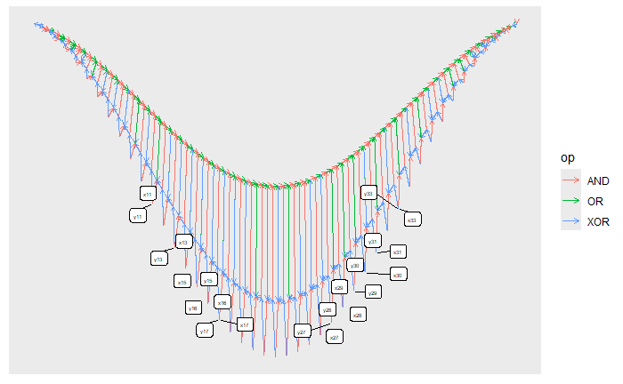

```
gatecheck()
```

```
x00 XOR y00 z00
x00 AND y00 kqn ->
y01 XOR x01 knr ->  kqn XOR knr z01 //  kqn AND knr fhg ->  fhg OR stk mkg
                    x01 AND y01 stk ->

y02 XOR x02 sbv ->  mkg XOR sbv z02 //  mkg AND sbv wwd ->  wwd OR mrq gfq
                    y02 AND x02 mrq ->

y03 XOR x03 kfr ->  gfq XOR kfr z03 //  kfr AND gfq fdc ->  fdc OR ttq mwb
                    x03 AND y03 ttq ->

y04 XOR x04 ffw ->  ffw XOR mwb z04 //  mwb AND ffw kdq ->  pvm OR kdq ctv
                    x04 AND y04 pvm ->

x05 XOR y05 mpk ->  mpk XOR ctv z05 //  mpk AND ctv bnb ->  bnb OR qjv scp
                    y05 AND x05 qjv ->

y06 XOR x06 gbp ->  scp XOR gbp z06 //  scp AND gbp ctg ->  vwr OR ctg kkp
                    x06 AND y06 vwr ->

y07 XOR x07 jcn ->  kkp XOR jcn z07 //  kkp AND jcn ckb ->  ckb OR wjk pcr
                    x07 AND y07 wjk ->

y08 XOR x08 kqg ->  pcr XOR kqg z08 //  kqg AND pcr dpf ->  dpf OR hdk nqv
                    x08 AND y08 hdk ->

x09 XOR y09 dqr ->  nqv XOR dqr z09 //  dqr AND nqv bgg ->  wtn OR bgg bjg
                    y09 AND x09 wtn ->

y10 XOR x10 qqp ->  qqp XOR bjg z10 //  bjg AND qqp dsp ->  dsp OR jpc frp
                    x10 AND y10 jpc ->

y11 XOR x11 sqv ->  frp XOR sqv z11 //  sqv AND frp tqm ->  mjt OR tqm svd
                    x11 AND y11 mjt ->

x12 XOR y12 ngj ->  ngj XOR svd z12 //  svd AND ngj gsb ->  gsb OR cqg rwd
                    y12 AND x12 cqg ->

y13 XOR x13 ktt ->  rwd XOR ktt z13 //  rwd AND ktt fps ->  fps OR qgw kqb
                    x13 AND y13 qgw ->
```

[output cut: 78 more lines]

```

x40 XOR y40 jgv ->  jgv XOR hbm z40 //  jgv AND hbm brv ->  jth OR brv bng
                    y40 AND x40 jth ->

y41 XOR x41 rdd ->  bng XOR rdd z41 //  rdd AND bng bhq ->  bdj OR bhq wkv
                    x41 AND y41 bdj ->

y42 XOR x42 tkp ->  tkp XOR wkv z42 //  tkp AND wkv vdn ->  qfm OR vdn wbv
                    y42 AND x42 qfm ->

y43 XOR x43 vqt ->  vqt XOR wbv z43 //  wbv AND vqt dph ->  dph OR qsd ghh
                    y43 AND x43 qsd ->

x44 XOR y44 jkt ->  jkt XOR ghh z44 //  ghh AND jkt mmj ->  gwr OR mmj z45
                    y44 AND x44 gwr ->
```

Looking at the graph around 36, it looks like the AND & XOR are switched - so switching those back:

```
gates<-gateswitcher("gfv","hcm",gates)


gatesdf<-as.data.frame(matrix(nrow=0,ncol=4))
for(i in 1:length(gates)){gatesdf<-rbind(gatesdf,gates[[i]])}
colnames(gatesdf)<-c("a","op","b","c")
```

For some reason that I can’t understand, z is wrong unless I run this several times. That does not make sense. And yet, it’s happened multiple times.

```
x= 22344970157743
y= 28135262594079
x+y= 50480232751822
z= 50480232751822
      [,1] [,2] [,3] [,4] [,5] [,6] [,7] [,8] [,9] [,10] [,11] [,12] [,13] [,14] [,15]
xs       1    1    1    1    0    1    0    1    0     1     1     1     1     1     0
ys       1    1    1    1    1    0    0    0    0     0     1     0     0     1     0
added    0    1    1    1    0    0    1    1    0     1     0     0     0     1     1
zs       0    1    1    1    0    0    1    1    0     1     0     0     0     1     1
      [,1] [,2] [,3] [,4] [,5] [,6] [,7] [,8] [,9] [,10] [,11] [,12] [,13] [,14] [,15]
xs       0    0    1    0    0    0    0    0    0     0     0     0     1     1     0
ys       0    1    0    1    0    1    0    1    0     0     0     0     0     0     0
added    0    1    1    1    0    1    0    1    0     0     0     0     1     1     0
zs       0    1    1    1    0    1    0    1    0     0     0     0     1     1     0
      [,1] [,2] [,3] [,4] [,5] [,6] [,7] [,8] [,9] [,10] [,11] [,12] [,13] [,14] [,15]
xs       0    1    0    1    0    0    1    0    1     0     0     0     1     0     1
ys       1    1    0    1    1    0    1    0    0     1     1     0     0     1     1
added    1    0    1    0    0    1    0    1    1     1     1     0     1     1     0
zs       1    0    1    0    0    1    0    1    1     1     1     0     1     1     0
```

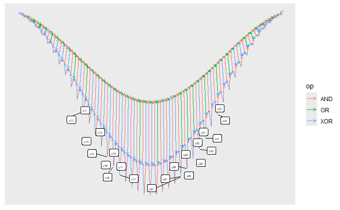